# Lecture 3 - HH Neuron

Author: Matthew J. Cossley

Last update: 10 March, 2021

## Electrophysiology of Neurons

- Key ionic players in membrane potential dynamics
  - Na$^+$
  - K$^+$
  - Ca$^{2+}$
  - Cl$^-$
  - A$^-$ (organic ions).
- Extracellular medium is high in Na$^+$, Cl$^-$ and to a lesser extent Ca$^{2+}$.
- Intracellular medium is high in K$^+$ and A$^-$.
- Two primary forces act on these ions:
  - Diffusion tries to mix everything up
  - Electrostatic pressure tries to split up positive from negative charges.
- These two forces must operate within the bounds of the cell architecture:
  - Channels in the cell membrane permit the flow of Cl$^-$ and k$^+$.
  - A$^-$, which is stuck on the inside of the cell, repels Cl$^-$ and attracts K$^+$ and Na$^+$.
  - Na$^+$-$K^+$ pumps push three Na$^+$ ions out of the cell in exchange for pumping two K$^+$ ions into the cell.
- For each ion type, diffusion and electrostatic pressure work against each other, and at some point, the diffusion forces and electrostatic forces are equal and opposite. At this point, net ion flow is zero.
- The membrane potential at which the flow of a particular ion is zero is called the Nernst equilibrium potential or the reversal potential and is denoted $E$.
- For any particular ion, the net ionic flow or current is proportional to the difference between the membrane potential and the reversal potential for that ion.

$$I_{ion} = g_{ion} (V - E_{ion})$$

- $V$ is the membrane potential, $g_{ion}$ is called the *conductance* and $(V - E_{ion})$ is called the driving force.
- The total current across a patch of membrane is given by:

$$I = C \frac{dV}{dt} + I_{Na} + I_{Ca} + I_{K} + I_{Cl}$$

- $C$ is the membrane capacitance and $C \frac{dV}{dt}$ is the capacitive current.
- It’s now easy to get an expression for the change in membrane potential over time.

$$C \frac{dV}{dt} = I - I_{Na} - I_{CA} - I_{K} - I_{CL} \\$$

- We now have a differential equation in a familiar form. We will use Euler’s method to get $V(t)$.

$$\begin{align}
V(t_2) &\approx V(t_1) + \frac{dV}{dt}\Bigg\rvert_{t=t_1} \Delta t \\
&\approx V(t_1) + (I - I_{Na} - I_{CA} - I_{K} - I_{CL}) / C \Bigg\rvert_{t=t_1} \Delta t
\end{align}$$

- In `python` this would look something like this:

```python
import numpy as np

tau = 1 # how many seconds one computer step represents

t = np.arange(0, 100, tau) # initialise time array

v = np.zeros(t.shape) # initialise potential with zeros
vr = -80 # define initial membrane potential
v[0] = vr # set initial membrane potential

for i in range(1, t.shape[0]):
  # dv/dt = (I - Ii) / C
  dvdt = 0 # we don't yet have enough information for this term

  # delta t
  dt = t[i] - t[i-1]

  # Euler's update
  v[t] = v[t-1] + dvdt * dt
```

- To proceed unpacking these terms fully so that we can program it up using Euler’s method, we express currents in terms of their conductances as follows:

$$C \frac{dV}{dt} = I - g_{Na} (V - E_{Na})
- g_{Ca} (V - E_{Ca})
- g_{K} (V - E_{K})
- g_{Cl} (V - E_{Cl})$$

- However, it turns out that membrane conductances (i.e., the $g_{i}$ terms) are not static. Rather, they change over time as a function of $V$, and they do this through the operation of so-called activation and inactivation gates.
- Activation gates are voltage-gated membrane channels that permit a particular ion flow when certain voltages are sensed.
- Inactivation gates are like activation gates but they block ion flow when certain voltages are reached.
- The proportion of open channels in a large population is given by:

$$p = m^a h^b$$

- $m$ is the probability of an activation gate being open, $h$ is the probability of an inactivation gate being open, $a$ is the number of activation gates and $b$ is the number of inactivation gates per channel.
- We can now express membrane potential in terms of $m$ and $h$ as follows:

$$C \frac{dV}{dt} = I - \overline{g}_{Na} m_{Na}^a h_{Na}^b (V - E_{Na})
- \overline{g}_{Ca} m_{K}^a h_{Ca}^b (V - E_{Ca})
- \overline{g}_{K} m_{K}^a h_{K}^b (V - E_{K})
- \overline{g}_{Cl} m_{K}^a h_{Cl}^b (V - E_{K})$$

- Here, the $\overline{g}_i$ terms are mean conductances and can be measured experimentally.
- Specifying how membrane conductance changes with $V$ over time is equivalent to stating how $m$ and $h$ change over time. Both follow simple differential equations as follows:

$$\frac{d}{dt}m = (m_{\infty}(V) - m) / \tau(V) \\
\frac{d}{dt}h = (h_{\infty}(V) - h) / \tau(V)$$

- $m_{\infty}(V)$ and $h_{\infty}$ are called steady-state terms and $\tau(V)$ is a time constant. Both can be measured experimentally.

## Hodgkin-Huxley math

- Hodgkin and Huxley (1952) determined that the squid axon carries three major currents:
  - voltage-gated persistent K$^+$ current with 4 activation gates
  - voltage-gated transient Na$^+$ current with 3 activation gates and 1 inactivation gate
  - leak current carried mostly by Cl$^-$ ions
- From the work covered in the previous section, we can write:

$$C \frac{dV}{dt} = I - \overline{g}_{K} n^4 (V - E_{K})
- \overline{g}_{Na} m^3 h (V - E_{Na})
- \overline{g}_{L} (V - E_{L})\\
\frac{d}{dt}n = (n_{\infty}(V) - n) / \tau(V) \\
\frac{d}{dt}m = (m_{\infty}(V) - m) / \tau(V) \\
\frac{d}{dt}h = (h_{\infty}(V) - h) / \tau(V) \\$$

- All that remains to specify are the steady-state and time-constant terms, which were measured experimentally by HH to be the following:

$$n_{\infty}(V) = \frac{\alpha_n(V)}{\alpha_n(V) + \beta_n(V)} \\
m_{\infty}(V) = \frac{\alpha_m(V)}{\alpha_m(V) + \beta_m(V)} \\
h_{\infty}(V) = \frac{\alpha_n(V)}{\alpha_h(V) + \beta_h(V)} \\$$

$$\tau_n = \frac{1}{\alpha_n(V) + \beta_n(V)} \\
\tau_m = \frac{1}{\alpha_m(V) + \beta_m(V)} \\
\tau_h = \frac{1}{\alpha_h(V) + \beta_h(V)}$$

- Here, the $\alpha$ and $\beta$ terms are function of $V$ given by the following:

$$\begin{align}
\alpha_h(V) &= 0.07 e^{\frac{(V_{\text{rest}} - V)}{20}}\\
\alpha_m(V) &= \frac{2.5 - 0.1 (V - V_{\text{rest}})}{e^{2.5 - 0.1(V-V_{\text{rest}})} - 1}\\
\alpha_n(V) &= \frac{0.1 - 0.01 (V - V_{\text{rest}})}{e^{1 - 0.1(V-V_{\text{rest}})} - 1}\\
\end{align}$$

$$\begin{align}
\beta_h(V) &= \frac{1}{1 + e^{3 - 0.1 (V - V_{\text{rest}})}}\\
\beta_m(V) &= 4 e^\frac{{(V_{\text{rest}}-V)}}{18}\\
\beta_n(V) &= 0.125 e^\frac{{(V_{\text{rest}}-V)}}{80}\\
\end{align}$$

- HH phrased things in the following mathematically equivalent way:

$$C \frac{dV}{dt} = I - \overline{g}_{K} n^4 (V - E_{K})
- \overline{g}_{Na} m^3 h (V - E_{Na})
- \overline{g}_{L} (V - E_{L})\\
\begin{align}
\frac{dh}{dt} &= \alpha_h(V)(1-h) - \beta_h(V)h\\
\frac{dm}{dt} &= \alpha_m(V)(1-m) - \beta_m(V)m\\
\frac{dn}{dt} &= \alpha_n(V)(1-n) - \beta_n(V)n\\
\end{align}$$

- In either forumation, the parameters are the same:

$$\overline{g}_{K} = 36 \text{ mS/cm$^2$} \\
\overline{g}_{Na} = 120 \text{ mS/cm$^2$} \\
\overline{g}_{L} = 0.3 \text{ mS/cm$^2$}$$

## Hodgkin-Huxley `Python`

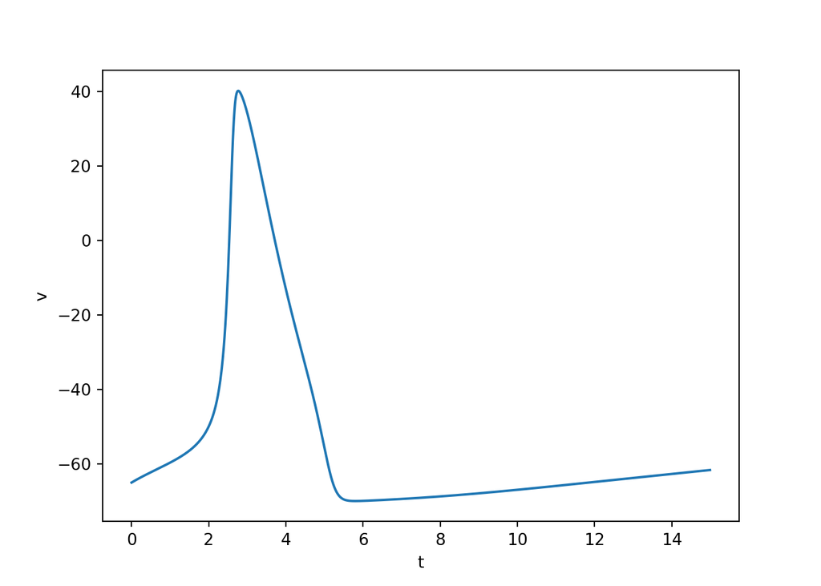

```python
import numpy as np
import matplotlib.pyplot as plt

tau = 0.01 # how many ms one computer step represents
T = 15 # total ms of the simulation
t = np.arange(0, T, tau) # initialise time array

h = np.zeros(t.shape)
m = np.zeros(t.shape)
n = np.zeros(t.shape)

v = np.zeros(t.shape) # initialise potential with zeros
vr = -65 # define initial membrane potential
v[0] = vr # set initial membrane potential

I = [4] * t.shape[0]
C = 50

g_na = 120
g_k = 36
g_leak = 0.3

E_na = 115 + vr
E_k = -6 + vr
E_leak = 10.6 + vr

def alpha_func_h(v):
  y = 0.07 * np.exp((vr - v)/20)
  return y


def alpha_func_m(v):
  y = (2.5-0.1*(v-vr))/ (np.exp(2.5-0.1*(v-vr))-1)
  return y


def alpha_func_n(v):
  y = (0.1-0.01*(v-vr))/ (np.exp(1.0-0.1*(v-vr))-1)
  return y


def beta_func_h(v):
  y = 1/(1+np.exp(3-0.1*(v-vr)))
  return y


def beta_func_m(v):
  y = 4 * np.exp((vr-v)/18)
  return y


def beta_func_n(v):
  y = 0.125*np.exp((vr-v)/80)
  return y

h[0] = alpha_func_h(vr) / (alpha_func_h(vr) + beta_func_h(vr))
m[0] = alpha_func_m(vr) / (alpha_func_m(vr) + beta_func_m(vr))
n[0] = alpha_func_n(vr) / (alpha_func_n(vr) + beta_func_n(vr))

for i in range(1, t.shape[0]):

  I_na = g_na * h[i-1] * m[i-1]**3 * (v[i-1] - E_na)
  I_k = g_k * n[i-1]**4 * (v[i-1] - E_k)
  I_leak = g_leak * (v[i-1] - E_leak)

  dvdt = I[i-1] - (I_na + I_k + I_leak)

  dhdt = alpha_func_h(v[i-1]) * (1 - h[i-1]) - beta_func_h(v[i-1]) * h[i-1]
  dmdt = alpha_func_m(v[i-1]) * (1 - m[i-1]) - beta_func_m(v[i-1]) * m[i-1]
  dndt = alpha_func_n(v[i-1]) * (1 - n[i-1]) - beta_func_n(v[i-1]) * n[i-1]

  # delta t
  dt = t[i] - t[i-1]

  # Euler's update
  v[i] = v[i-1] + dvdt * dt
  h[i] = h[i-1] + dhdt * dt
  m[i] = m[i-1] + dmdt * dt
  n[i] = n[i-1] + dndt * dt

fig, ax, = plt.subplots(1, 1, squeeze=False)
ax[0, 0].plot(t, v)
ax[0, 0].set_ylabel('v')
ax[0, 0].set_xlabel('t')
plt.show()
```